# Peripatetic Networks

19/05/2021

## The ‘Networking Archives’ Team

- Worked is based on a larger project, thanks to (clockwise from left): Howard Hotson (Principal Investigator), Miranda Lewis, Matthew Wilcoxson, Arno Bosse, Philip Beeley, Ruth Ahnert (Co-Investigator), Sebastian Ahnert (Co-Investigator), Esther van Raamsdonk (http://networkingarchives.org/project-team/)

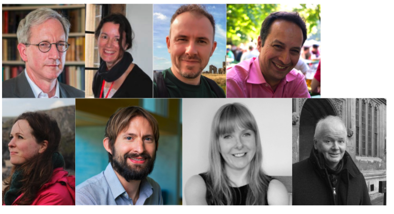

## Historical and spatial networks

- Interest in Historical Network Analysis (HNR), also seen interest in understanding spatial and temporal dimensions of networks
- Spatial information in networks used to map letter origins or paths
- Or used as a weight function in a network
- Richard White, Spatial History Lab:

> I don’t want to be so simplistic as to say that if space is the question then movement is the answer, but I fear that I am nearly that simple. (Richard White,‘What is Spatial History?’, 2010)
- I propose a number of ways in which we can incorporate *movement* into networks

## The Data Used

### Early Modern Letters Online

- A union of c.100 catalogues brought together to study the Republic of Letters (1500-1800 but focus in 17th century)
- Letters from across Europe, focus in particular on Dutch correspondence

### State Papers Online

- Digitised Calendars of scans of the State Papers from Britain and Ireland, Tudor and Stuart Periods (1509 - 1714)
- SP might be thought of as the principal and working library for the Parliamentary executive
- Both domestic and foreign papers

## Geographic data

- Out of 470,000 records, 295,000 have sets of coordinates for letter origin; about 57,000 also with destination information
- Letters mostly in Britain, Ireland, Continental Europe but also America, India etc.
- Information used to map the geography of the letter archives:
  - EMLO is particularly European, with a concentration in the Low Countries
  - State Papers Stuart more English: mostly domestic state papers
  - Tudor slightly more European-focus, also Dublin and Edinburgh

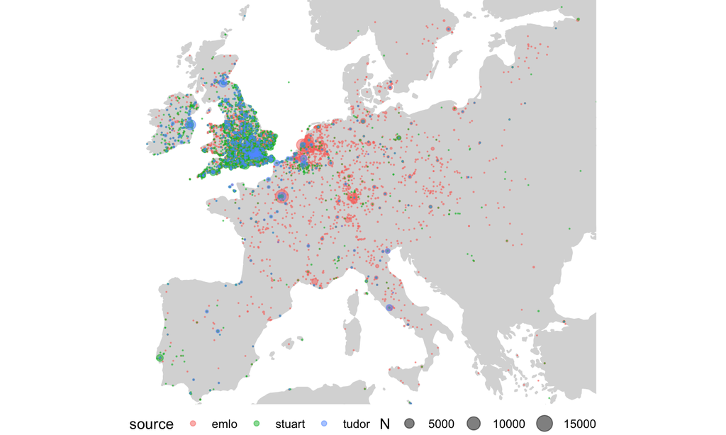

## Movement in early modern Europe

- 17th century was a time of movement for many
  - Growth of the postal system meant letters could be carried across increasingly large distances at less cost
  - Elites in Britain conducted ‘Grand Tours’ of the continent
  - Diplomatic missions could mean travelling across Europe for months at a time
  - Also those displaced by the 30 years war, which involved much of continental Europe and resulted in armies, refugees constantly moving.

## Tracing Movement

- Some of this movement can be traced through correspondence data.
- We calculate an ‘itinerary’ for each person in the dataset
- Then measured the distance of each route, as the crow flies

## Tracing Movement

18 Oct 1635: Dury, John, 1596-1680 (The Hague, South Holland, Netherlands) to Roe, Thomas (Sir), 1581-1644

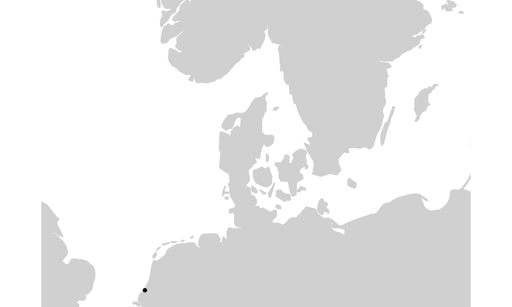

## Tracing Movement

7 Apr 1636: Dury, John, 1596-1680 (Amsterdam, North Holland, (United Provinces) Netherlands) to Godemann, Caspar, fl. 1631-1643 (London, England)

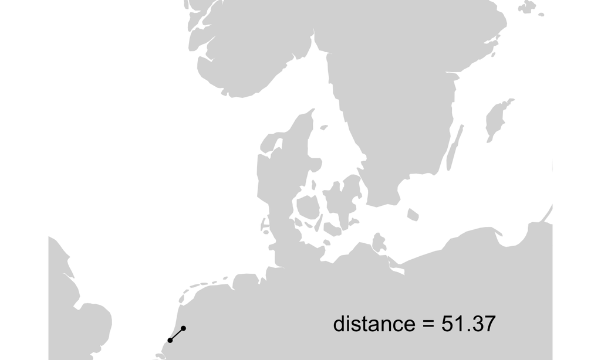

## Tracing Movement

29 May 1636: Dury, John, 1596-1680 (Norrköping, Östergötland, Sweden) to Roe, Thomas (Sir), 1581-1644 (London, England)

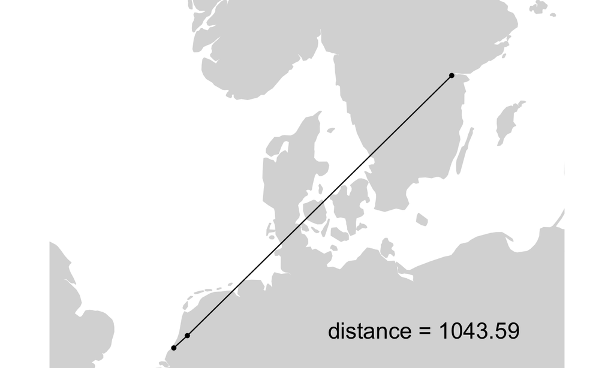

## Tracing Movement

3 Jun 1636: Dury, John, 1596-1680 (Stockholm, Stockholm Municipality, Sweden) to Hartlib, Samuel, 1600-1662 (London, England)

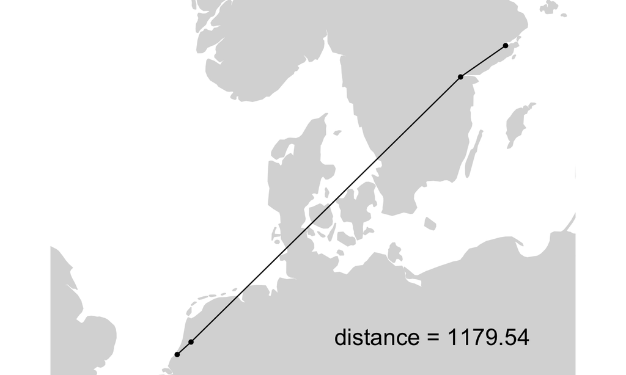

## Results

- Transform this into a ‘simple features’ spatial object of linestrings
- Allows all ‘itineraries’ to be mapped and their distances measured.
- Captures a variety of movement such as Thomas Windebank and Thomas Roe

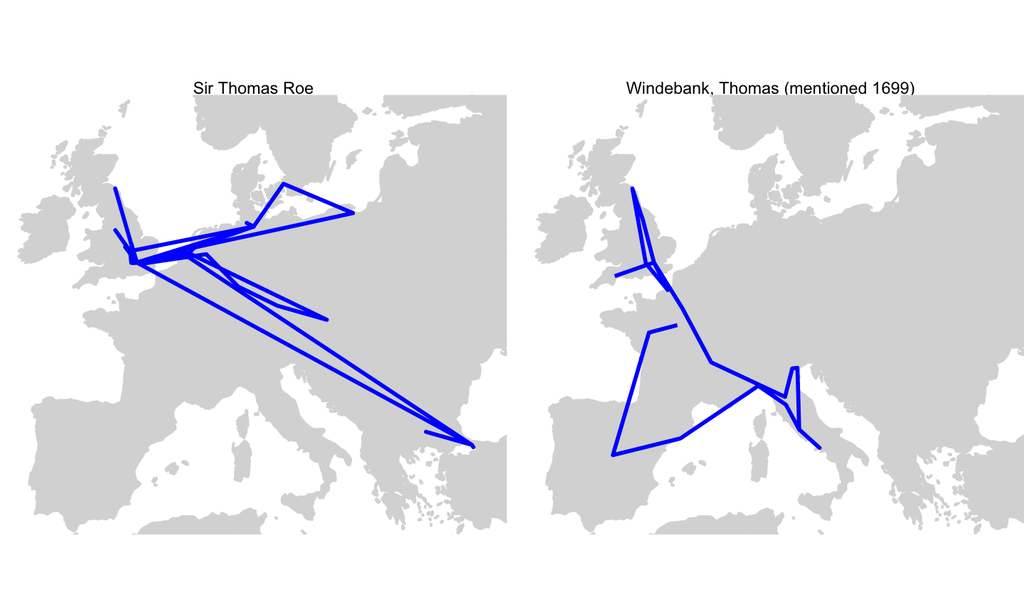

## Tracing Movement

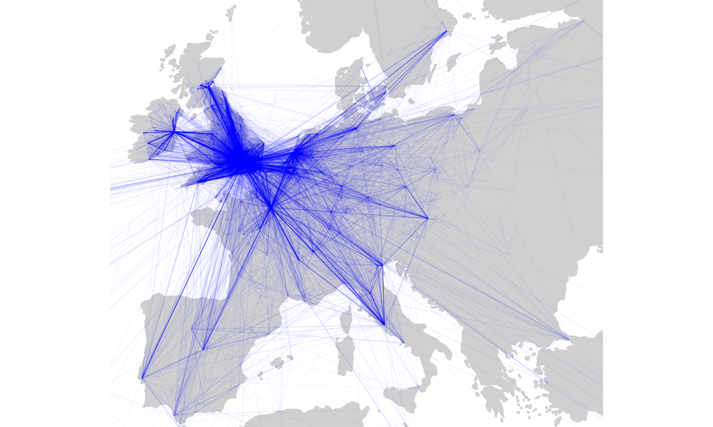

## Mobility and Networks

- Next I was interesting in investigating the relationship between this mobility and network centrality measures.
- Calculated Spearman correlations between distance rank and centrality ranks
- Moderate correlation can be found (I consider this a non-result)

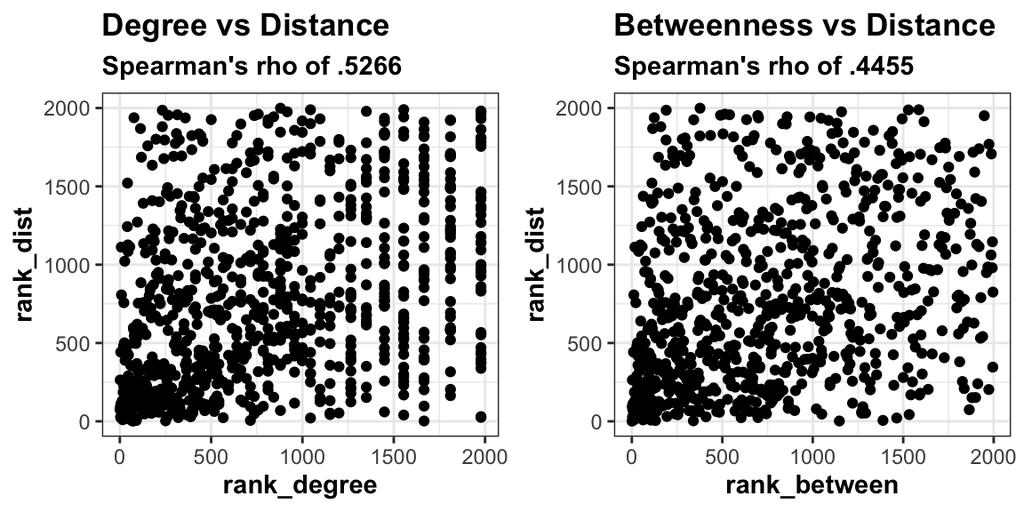

## Mobility over time

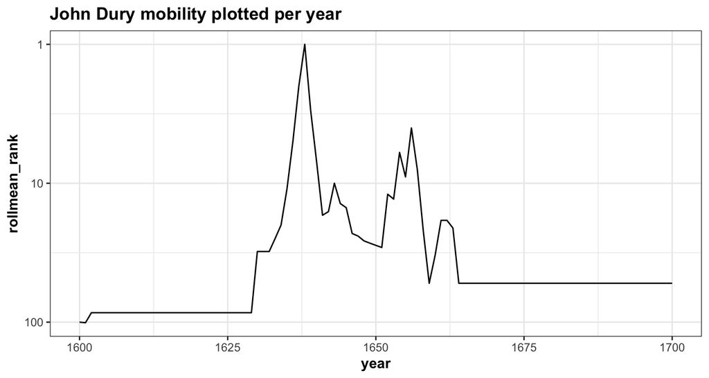

## Mobility and network metrics

- Allows us to assess effects of mobility and travel on networks in 17th century
- Compared network and mobility scores
- In Dury for example, increased degree centrality follows closely behind increased mobility: travel was a way of establishing new contacts.

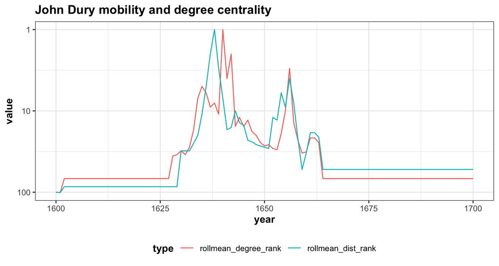

## Looking systematically for movement influencing centrality scores

- Looked for short periods with high correlation between mobility and degree
- Calculated Pearson’s values for 4-year rolling window
- Also calculate with 2-year lag and lead (looking for cases where a burst of travel precipitated an expanding network)

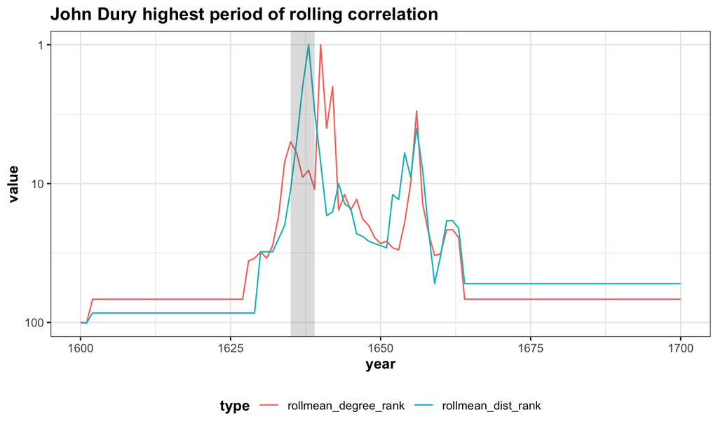

## Looking closer at the relationship between degree and mobility

- To estimate the effect of travel on networks, wrote a function which removes edges from a selected period, recalculates centrality scores for a given node, and lists individuals who they had contact with again after the travel period ended.
- Function compares the change in ranks if a period of travel had not happened
- For Dury between 1636-1639, many of his important connections were during this tour of the Netherlands and Sweden.

Contacts up to that point: 82 Contacts during voyage: 23 (14 for the first time) 6 were a contact again after the voyage: St Amand, Joseph (300756) Groot, Hugo de (900019) Dingley, John (300342) Rusdorf, Johann Joachim von (300175) Laud, William (300290) Oxenstierna, Axel (Count) (300658)

CHANGES degree rank before: 26 degree_rank_after: 28 Change: -2 Betweenness rank before: 21 Betweenness rank after: 24 Change: -3 Eigen centrality rank before: 18 Eigen centrality rank after: 24 Change: -6

## Conclusions

- In historical networks understanding networks with respect to movement is as important as a typical spatial perspective
- Comparing the two has shown:
  - Movement does not necessarily correlate with network centralities but it can do
  - Rolling correlations help to understand periods where the two match up